# IE6400 Foundations for Data Analytics Engineering

# Fall 2023

### Module 2: Statistical Experiments and Significance Testing

### - READING -

**NumPy** is a fundamental package for scientific computing with Python. It provides support for arrays, matrices, and a collection of mathematical functions to operate on these arrays.

**Matplotlib** is a popular library for creating static, animated, and interactive visualizations in Python.

**SciPy** is an open-source library for mathematics, science, and engineering. It builds on NumPy and provides additional functionality for optimization, integration, interpolation, eigenvalue problems, and more.

#### 1 - Measures of Central Tendency

The **mean** of a data set is the sum of the data entries divided by the number of entries. To find the mean of a data set, use one of these formulas.

Population Mean: $\mu = \frac{\Sigma x}{N}$

Sample Mean: $\bar{x} = \frac{\Sigma x}{n}$

The lowercase Greek letter $\mu$ (pronounced mu) represents the population mean and $\bar{x}$ (read as “x bar”) represents the sample mean. Note that $N$ represents the number of entries in a $\textit{population}$ and $n$ represents the number of entries in a $\textit{sample}$. Recall that the uppercase Greek letter sigma ($\Sigma$) indicates a summation of values.

#### 2 - Measures of Variation

The **population variance** of a population data set of $N$ entries is

Population variance $= \sigma^2 = \frac{\Sigma(x - \mu)^2}{N}$

The symbol $\sigma$ is the lowercase Greek letter sigma.

The **population standard deviation** of a population data set of $N$ entries is the square root of the population variance.

Population standard deviation $= \sigma = \sqrt{\sigma^2} = \sqrt{\frac{\Sigma(x - \mu)^2}{N}}$

The **sample variance** and **sample standard deviation** of a sample data set of $n$ entries are listed below.

Sample variance $= s^2 = \frac{\Sigma(x - \bar{x})^2}{n - 1}$

Sample standard deviation $= s = \sqrt{s^2} = \sqrt{\frac{\Sigma(x - \bar{x})^2}{n - 1}}$

A normal distribution is a probability distribution that is centered around the mean. The distribution is symmetrical, bell-shaped, and has a single mode or peak. The mean, median, and mode are all equal. The distribution decreases as you move away from the center. The normal distribution is also known as the Gaussian distribution or probability bell curve. It is used to analyze data when there is an equally likely chance of being above or below the mean. The standard normal distribution is a normal distribution represented in z scores. It always has a mean of zero and a standard deviation of one

**Note**: The normal distribution with a mean of 0 and a standard deviation of 1 is called the **standard normal distribution**.

#### 3 - Sampling Distributions and the Central Limit Theorem

The mean of the sample means $\mu_{\bar{x}}$ is equal to the population mean $\mu$.

$\mu_{\bar{x}} = \mu$

The standard deviation of the sample means $\sigma_{\bar{x}}$ is equal to the population standard deviation $\sigma$ divided by the square root of the sample size $n$.

$\sigma_{\bar{x}} = \frac{\sigma}{\sqrt{n}}$

is called the **standard error of the mean**.

#### The Central limit theorem

- If random samples of size $n$, where $n \ge 30$, are drawn from any population with a mean $\mu$ and a standard deviation $\sigma$, then the sampling distribution of sample means approximates a normal distribution. The greater the sample size, the better the approximation
- If random samples of size $n$ are drawn from a population that is normally distributed, then the sampling distribution of sample means is normally distributed for any sample size $n$.

In either case, the sampling distribution of sample means has a mean equal to the population mean.

$\mu_{\bar{x}} = \mu$

#### 4 - Confidence Intervals for the Mean ($\sigma$ Known)

A **point estimate** is a single value estimate for a population parameter. The most unbiased point estimate of the population mean $\mu$ is the sample mean $\bar{x}$.

#### Finding a Point Estimate

A researcher is collecting data about a college athletic conference and its student-athletes. A random sample of 40 student-athletes is selected and their numbers of hours spent on required athletic activities for one week are recorded. Find a point estimate for the population mean $\mu$, the mean number of hours spent on required athletic activities by all student-athletes in the conference.

### Solution

The sample mean of the data is

$\bar{x} = \frac{\Sigma x}{n} = \frac{842}{40} = 21.1$

So, the point estimate for the mean number of hours spent on required athletic activities by all student-athletes in the conference is about 21.1 hours

The point estimate for μ is the sample mean (often denoted as x̄), which is the average number of hours spent on **required athletic activities** by the **40 randomly selected student-athletes**.

#### Exercise

The probability that the population mean is exactly 21.1 is virtually zero. So, instead of estimating $\mu$ to be exactly 21.1 using a point estimate, you can estimate that $\mu$ lies in an interval. This is called making an interval estimate.

- An **interval estimate** is an interval, or range of values, used to estimate a population parameter.
- The **level of confidence** $c$ is the probability that the interval estimate contains the population parameter, assuming that the estimation process is repeated a large number of times.

The level of confidence $c$ is the area under the standard normal curve between the `critical values`, $-z_c$ and $z_c$.

**Critical values** are values that separate sample statistics that are probable from sample statistics that are improbable, or unusual.

- $c$ is the percent of the area under the normal curve between $-z_c$ and $z_c$. The area remaining is $1 - c$, so the area in each tail is $\frac{1}{2}(1 - c)$.
- if $c = 90\%$, then $5\%$ of the area lies to the left of $-z_c = -1.645$ and $5\%$ lies to the right of $z_c = 1.645$.

#### 5 - Confidence Intervals for the Mean ($\sigma$ Unknown)

The **degrees of freedom** are the number of free choices left after a sample statistic such as $\bar{x}$ is calculated. When you use a $t$-distribution to estimate a population mean, the degrees of freedom are equal to one less than the sample size.

d.f. = $n - 1$

As the degrees of freedom increase, the $t$-distribution approaches the standard normal distribution. After 30 d.f., the $t$-distribution is close to the standard normal distribution.

#### Testing the Difference Between Means (Independent Samples,$\sigma_1$ and $\sigma_2$ Known)

#### Hypothesis Tests ,Key terms and their Types

Hypothesis tests, also called significance tests, are ubiquitous in the traditional statistical analysis of published research. Their purpose is to help you learn whether random chance might be responsible for an observed effect.

Key Terms

- Null hypothesis The hypothesis that chance is to blame.
- Alternative hypothesis Counterpoint to the null (what you hope to prove).
- One-way test Hypothesis test that counts chance results only in one direction.
- Two-way test Hypothesis test that counts chance results in two directions

Null Hypothesis (H0):

- Initial assumption of no effect or no difference.
- Represents what you aim to challenge or test.
- Often framed as equality (e.g., "no difference" or "equal to a specific value").

Alternative Hypothesis (Ha or H1):

- Contradicts the null hypothesis.
- Represents what you're trying to find evidence for.
- Often framed as inequality (e.g., "difference exists" or "not equal to a specific value").

In hypothesis testing, you analyze data to determine whether it provides enough evidence to reject the null hypothesis in favor of the alternative hypothesis, based on a significance level (α) and the calculated p-value.

A statistical hypothesis test may return a value called p or the p-value. This is a quantity that we can use to interpret or quantify the result of the test and either reject or fail to reject the null hypothesis. This is done by comparing the p-value to a threshold value chosen beforehand called the significance level

#### Confidence Interval and Significance Level Alpha

The significance level is often referred to by the Greek lower case letter alpha (α). A common value used for alpha is 5% or 0.05. A smaller alpha value suggests a more robust interpretation of the result, such as 1% or 0.1%. The p-value is compared to the pre-chosen alpha value. A result is statistically significant when the p-value is less than or equal to alpha. This signifies a change was detected: that the default or null hypothesis can be rejected.  p-value ≤ alpha: significant result, reject null hypothesis (H1).  p-value > alpha: not significant result, fail to reject the null hypothesis (H0). The significance level can be inverted by subtracting it from 1 to give a confidence level of the hypothesis given the observed sample data. confidence level = 1 − significance level

#### Errors in Statistical Tests

- Type I Error: The incorrect rejection of a true null hypothesis, called a false positive.
- Type II Error: The incorrect failure of rejecting a false null hypothesis, called a false negative.

#### T-Distribution and its Key Characteristics

The t-distribution, also known as Student's t-distribution, is a probability distribution commonly used in statistics when dealing with small sample sizes or situations where the population standard deviation is unknown. It is similar in shape to the normal distribution but has heavier tails, making it more appropriate for handling uncertainty associated with small samples.

**Key Characteristics of the t-Distribution**:

1. **Shape**: The t-distribution has a bell-shaped curve, similar to the normal distribution.
2. **Parameters**: It is characterized by a single parameter called degrees of freedom ((df)). The degrees of freedom determine the shape of the t-distribution. As (df) increases, the t-distribution approaches the shape of the normal distribution.
3. **Heavier Tails**: The t-distribution has heavier tails compared to the normal distribution. This means that there is a greater probability of extreme values occurring in small samples.

#### When to t-distribution ?

1. Dealing with relatively small sample sizes (n), typically less than 30.
2. The population standard deviation is unknown, making it necessary to use sample data to estimate population parameters.

#### Applications of the t-Distribution:

- **Confidence Intervals**
- **Hypothesis Testing**
- **Quality Control**
- **Biostatistics and Healthcare**
- **Economics and Finance**
- **Market Research**
- **Educational Assessment**
- **Environmental Science**
- **Social Sciences**
- **Sports and Fitness**

#### Exercise

Research Question 1: In the pursuit of estimating the average height of a specific population, a study is undertaken involving a random sample of 15 individuals from this population, with their heights measured. The objective is to construct a confidence interval for the population's mean height, utilizing the t-distribution. Given that the sample data yields a sample mean (x̄) of 168 cm and a sample standard deviation (s) of 5 cm, how can we determine a reliable range for the population mean height with a certain level of confidence?

#### Student’s t-Test

The Student's t-test is a statistical hypothesis test used to determine if there's a significant difference between the means of two groups. There are two main types:

1. **Independent Samples t-test**: Compares means of two unrelated groups (e.g., comparing test scores of two different classes).
2. **Paired Samples t-test**: Compares means of two related groups (e.g., before-and-after measurements for the same individuals).

The test involves formulating a null hypothesis (no difference), calculating a t-statistic, finding a p-value, and deciding whether to accept or reject the null hypothesis based on the p-value. It's widely used in research, spanning science, social sciences, business, and healthcare, to assess group differences.

#### Z-test

Z-Test: The z-test is a statistical hypothesis test used to determine whether the mean of a dataset is significantly different from a known population mean. It's particularly useful when you have a large sample size (typically n > 30) and know the population standard deviation. There are two main types of z-tests:

One-Sample Z-Test: This test is used to compare the sample mean to a known population mean when you have one sample. The formula for the z-test statistic is:

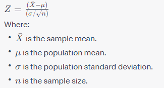

Two-Sample Z-Test: This test compares the means of two independent samples to determine if they are significantly different from each other. It's similar to the one-sample z-test but applied to two separate groups.

#### Chisquared test

Chi-square statistic A measure of the extent to which some observed data departs from expectation. It is not a symmetrical distribution its a screwed distribution. (Goodness of fit)

Revised Date: October 7, 2023